# Logistic Regression on German Credit dataset

Aiswarya_Alapuzha(D19002), Anugya Shaw(D19006)

30/01/2020

The assignment is for evaluating whether the customers tend to defualt or not on the credit offered to them. The dataset used in this model is the german credit dataset. We have performed end to end logistic regression.

Number of Attributes german: 20 (7 numerical, 13 categorical) Number of Attributes german.numer: 24 (24 numerical)

**Calling all the required libraries**

```r
library(xlsx)
library(InformationValue)
library(Information)
library(woeBinning)
library(dummies)
library(caTools)
library(ROCR)
library(oddsratio)
library(sqldf)
library(ResourceSelection)
```

```
## ResourceSelection 0.3-5   2019-07-22
```

```r
library(DMwR)
```

**Loading and viewing the data**

```r
setwd('C:\\Users\\Aiswarya\\Desktop\\2nd_sem\\MI_Assign')
credit = read.csv("germancredit.csv")
View(credit)
```

**Get a basic understanding of the dataset in hand**

```r
dim(credit)
```

```
## [1] 1000   21
```

```r
str(credit)
```

```
## 'data.frame':    1000 obs. of  21 variables:
##  $ Default_       : int  0 1 0 0 1 0 0 0 0 1 ...
##  $ checkingstatus1: Factor w/ 4 levels "A11","A12","A13",..: 1 2 4 1 1 4 4 2 4 2 ...
##  $ duration       : int  6 48 12 42 24 36 24 36 12 30 ...
##  $ history        : Factor w/ 5 levels "A30","A31","A32",..: 5 3 5 3 4 3 3 3 3 5 ...
##  $ purpose        : Factor w/ 10 levels "A40","A41","A410",..: 5 5 8 4 1 8 4 2 5 1 ...
##  $ amount         : int  1169 5951 2096 7882 4870 9055 2835 6948 3059 5234 ...
##  $ savings        : Factor w/ 5 levels "A61","A62","A63",..: 5 1 1 1 1 5 3 1 4 1 ...
##  $ employ         : Factor w/ 5 levels "A71","A72","A73",..: 5 3 4 4 3 3 5 3 4 1 ...
##  $ installment    : int  4 2 2 2 3 2 3 2 2 4 ...
##  $ status         : Factor w/ 4 levels "A91","A92","A93",..: 3 2 3 3 3 3 3 3 1 4 ...
##  $ others         : Factor w/ 3 levels "A101","A102",..: 1 1 1 3 1 1 1 1 1 1 ...
##  $ residence      : int  4 2 3 4 4 4 4 2 4 2 ...
##  $ property       : Factor w/ 4 levels "A121","A122",..: 1 1 1 2 4 4 2 3 1 3 ...
##  $ age            : int  67 22 49 45 53 35 53 35 61 28 ...
##  $ otherplans     : Factor w/ 3 levels "A141","A142",..: 3 3 3 3 3 3 3 3 3 3 ...
##  $ housing        : Factor w/ 3 levels "A151","A152",..: 2 2 2 3 3 3 2 1 2 2 ...
##  $ cards          : int  2 1 1 1 2 1 1 1 1 2 ...
##  $ job            : Factor w/ 4 levels "A171","A172",..: 3 3 2 3 3 2 3 4 2 4 ...
##  $ liable         : int  1 1 2 2 2 2 1 1 1 1 ...
##  $ tele           : Factor w/ 2 levels "A191","A192": 2 1 1 1 1 2 1 2 1 1 ...
##  $ foreign_       : Factor w/ 2 levels "A201","A202": 1 1 1 1 1 1 1 1 1 1 ...
```

```r
table(credit$Default_) #gives the number of 0's and 1's in the data
```

```
##
##   0   1
## 700 300
```

**Analyse the bad rate across the variable “credit history”**

```r
require(sqldf)
#Bad rate for credit history

sqldf("SELECT history, round(avg(Default_)*100,2) AS 'Bad Rate',
      (100 - round(avg(Default_)*100,2)) AS 'Good Rate',
      COUNT(*) AS 'No of Applicants'
      FROM credit GROUP BY history")
```

```
##   history Bad Rate Good Rate No of Applicants
## 1     A30    62.50     37.50               40
## 2     A31    57.14     42.86               49
## 3     A32    31.89     68.11              530
## 4     A33    31.82     68.18               88
## 5     A34    17.06     82.94              293
```

**Similarly calculating the bad rate for all the variables**

```r
library(xlsx)
wb = createWorkbook()

for(i in 2:ncol(credit))
{
  if(is.factor(credit[,i]))
  {

    varname = names(credit)[i]

    sheet = createSheet(wb, varname)

    string = paste("SELECT", varname, ", round(avg(Default_)*100,2) AS 'Bad Rate', (100 - round(avg(Default_)*100,2)) AS 'Good Rate' FROM credit GROUP BY", varname)

    addDataFrame(sqldf(string), sheet = sheet, startColumn = 2, row.names = F)

  }
}

saveWorkbook(wb, "Bad Rate.xlsx")
```

**Performing univariate analysis**

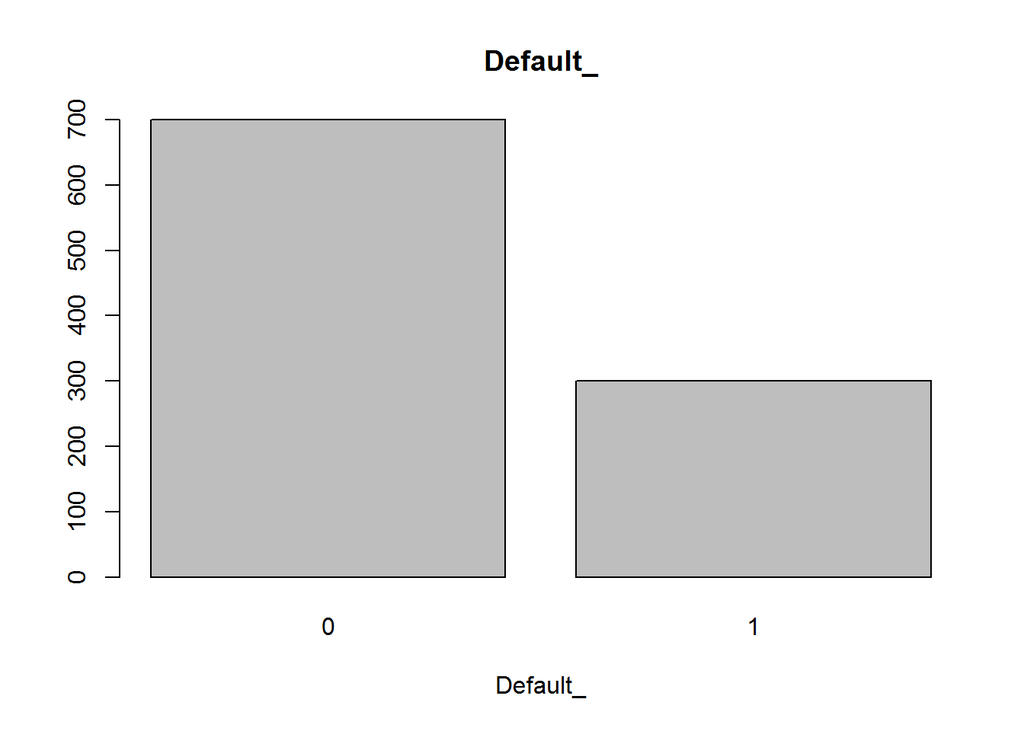

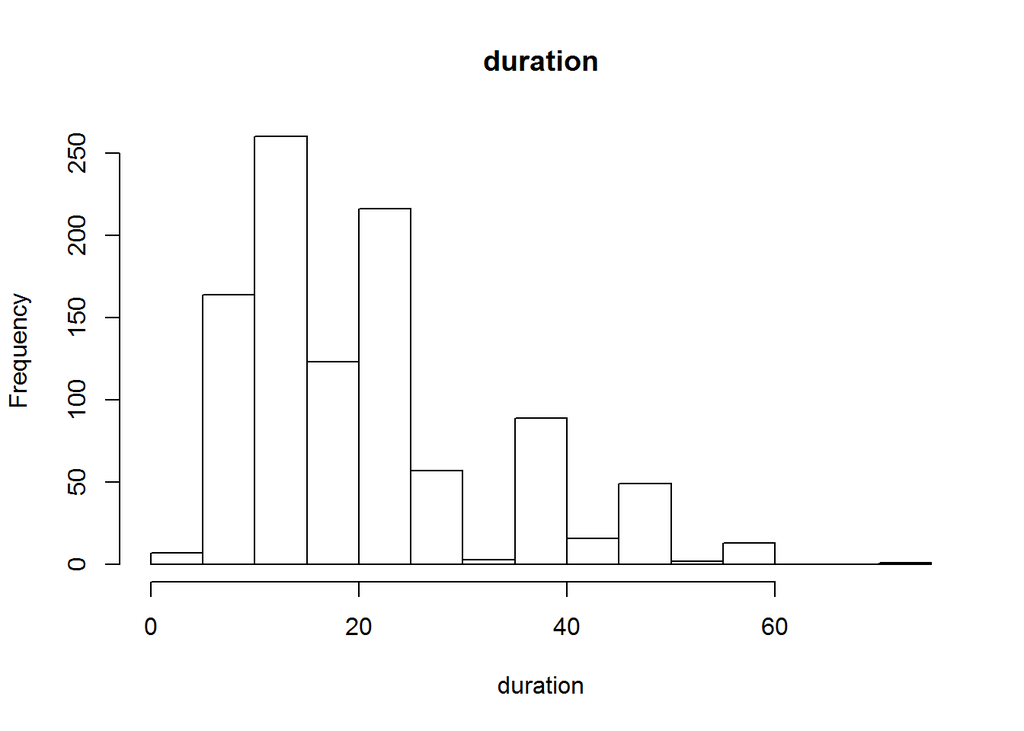

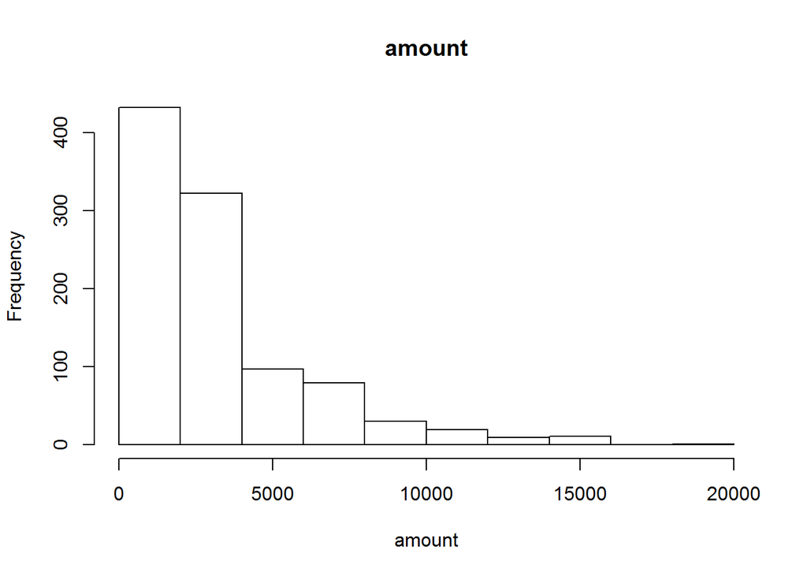

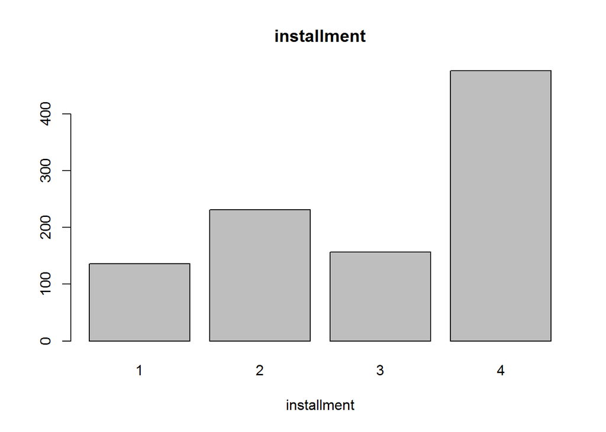

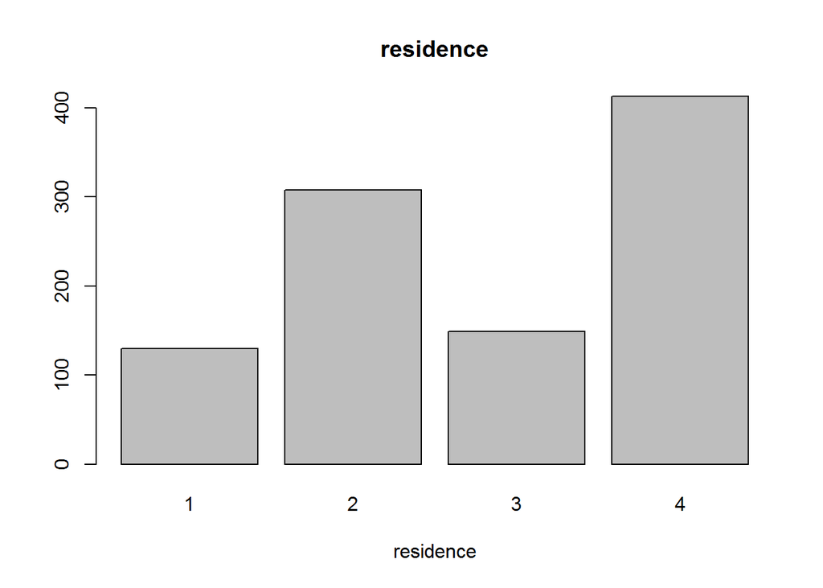

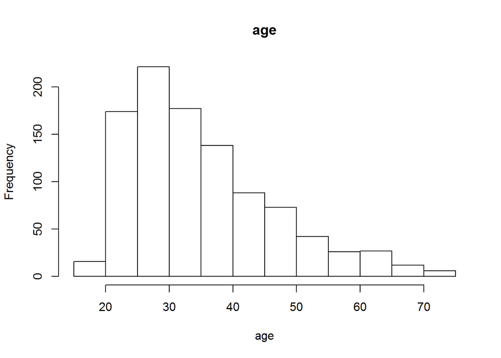

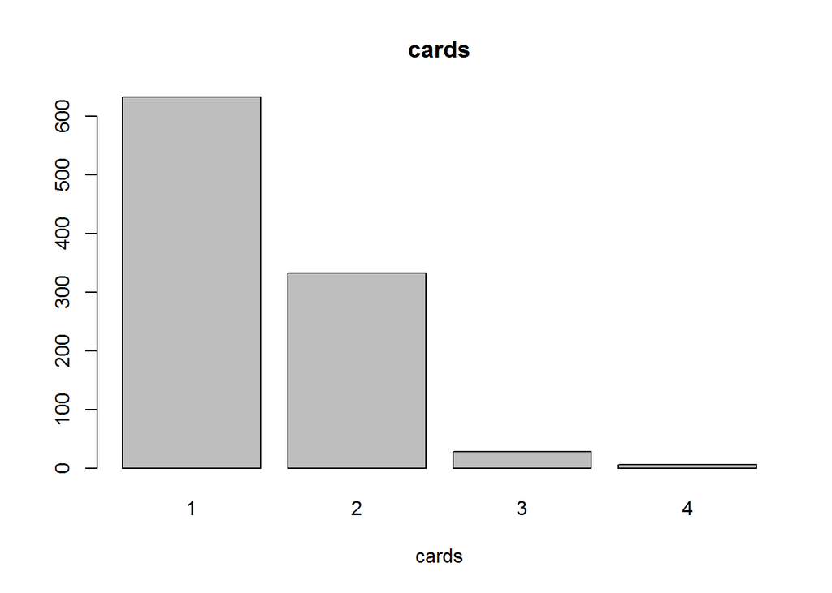

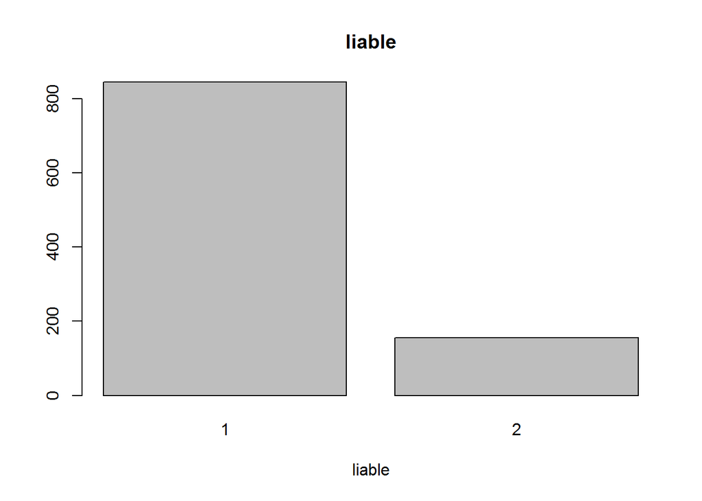

```r
#Histogram or barplots for numerical variables
for(i in 1:ncol(credit))
{
  if(is.numeric(credit[,i]))
  {
    if(length(unique(credit[,i])) > 10)
    {
      hist(credit[,i], main = names(credit)[i], xlab = names(credit)[i])
    }

    else if(length(unique(credit[,i])) < 10)
    {
      barplot(table(credit[,i]), main=names(credit)[i], xlab = names(credit)[i])
    }
  }
}
```

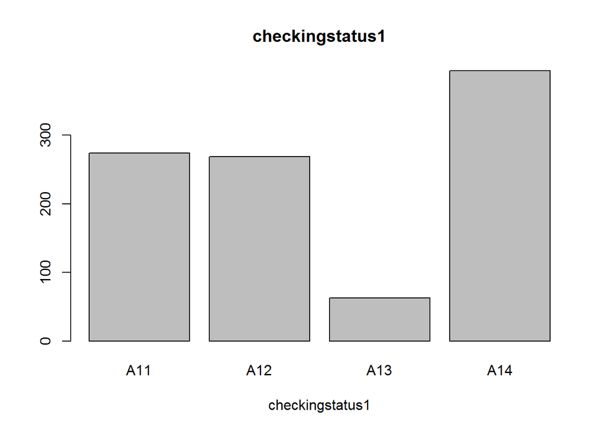

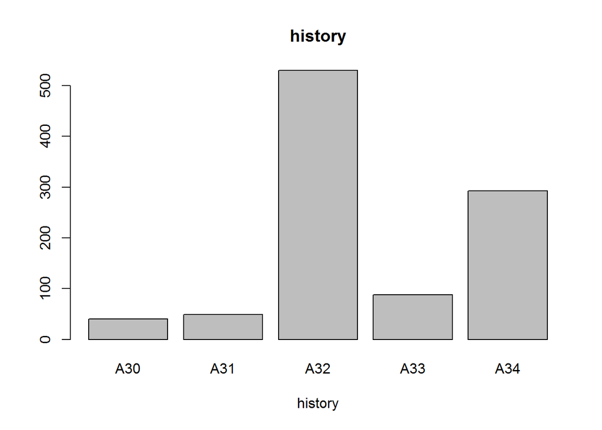

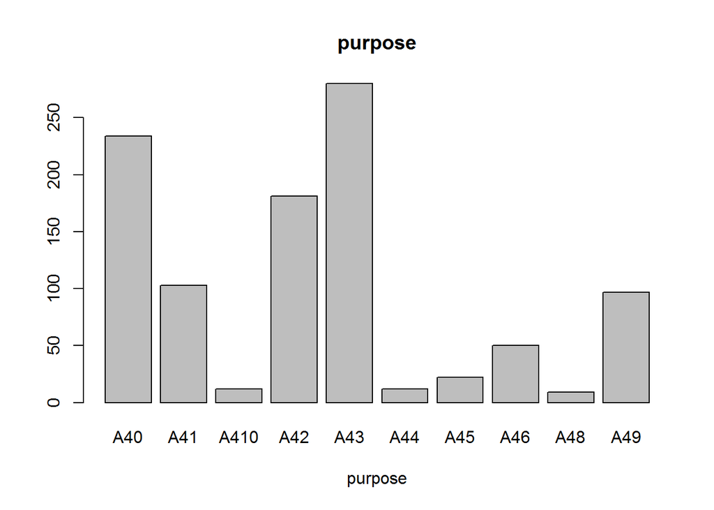

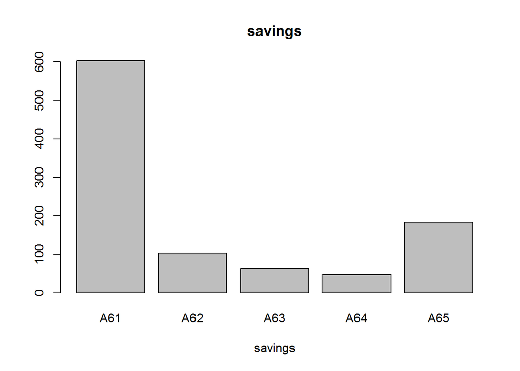

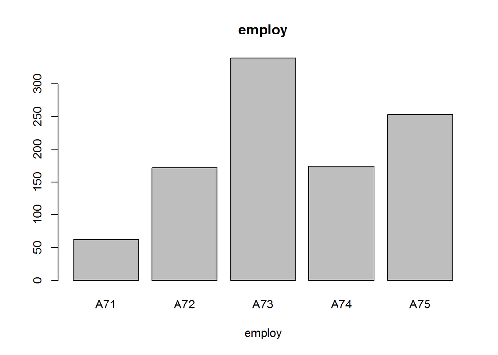

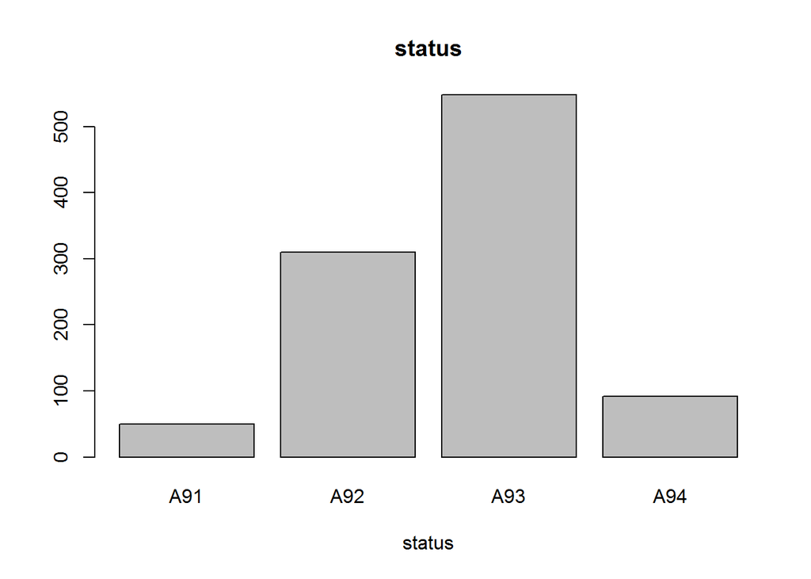

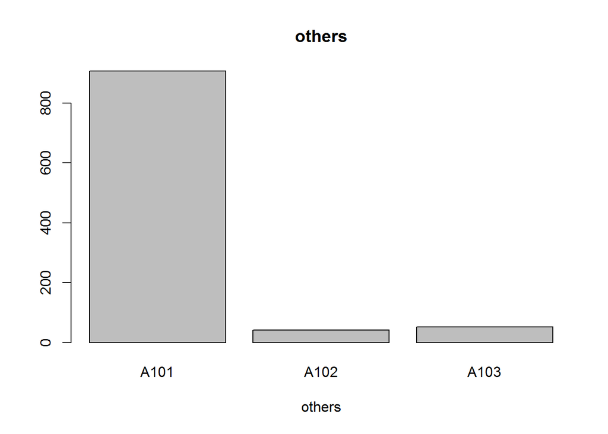

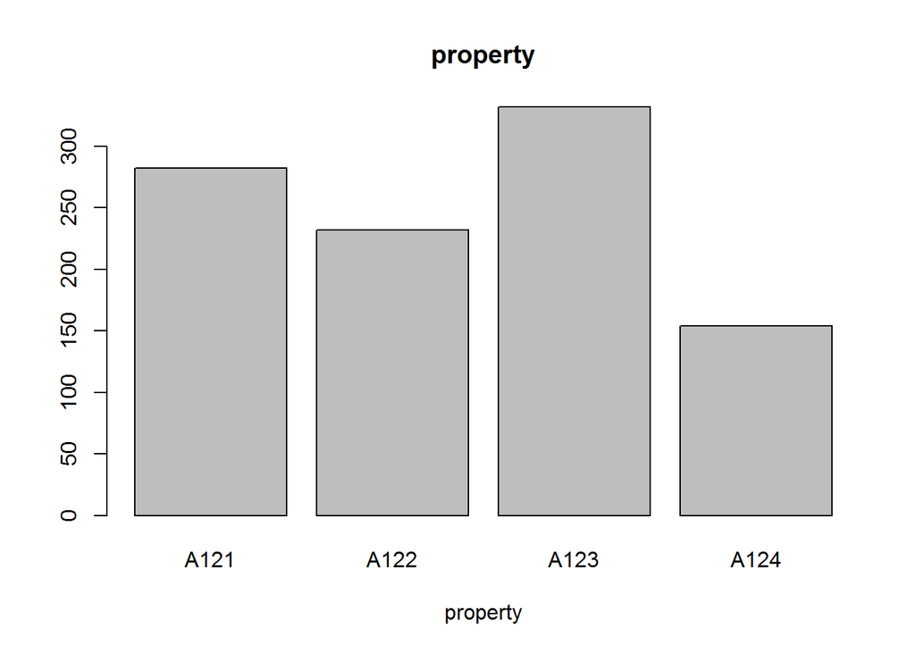

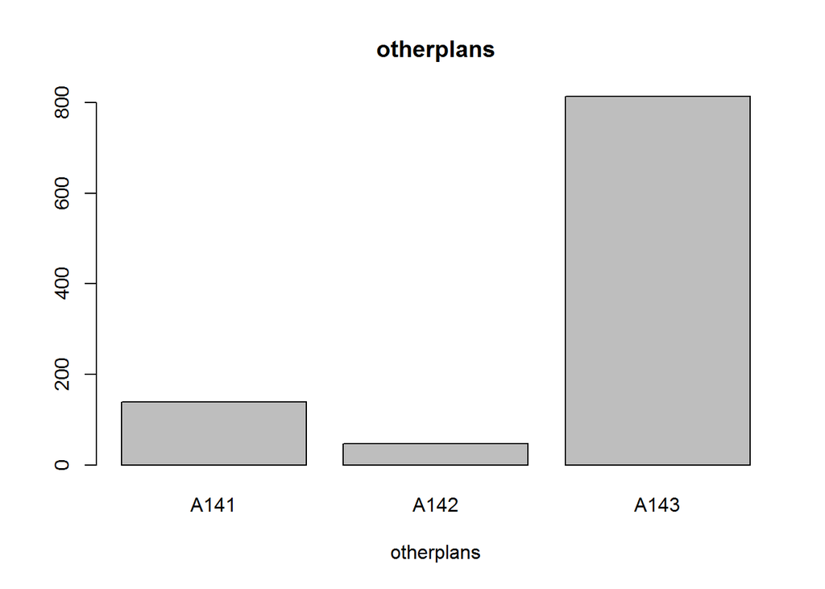

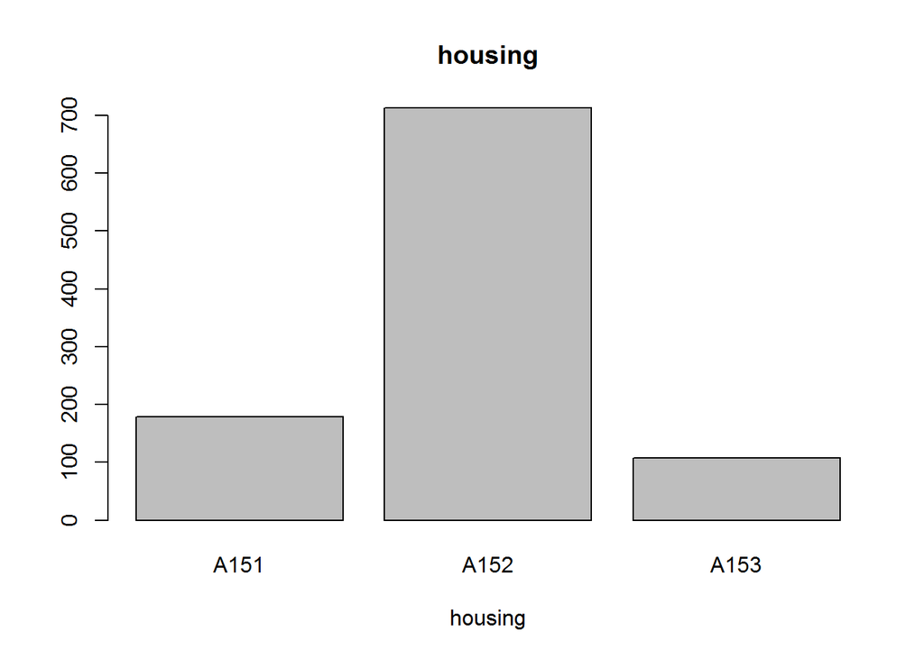

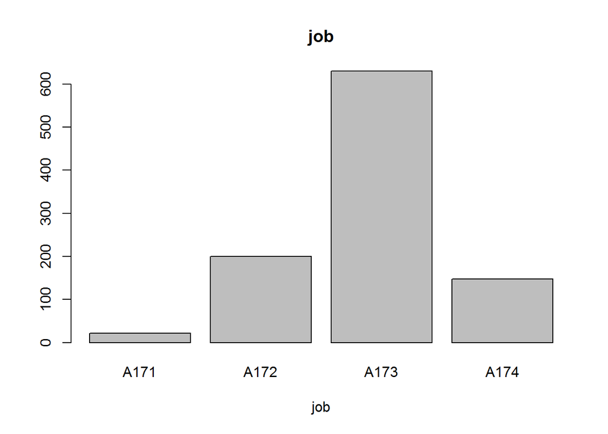

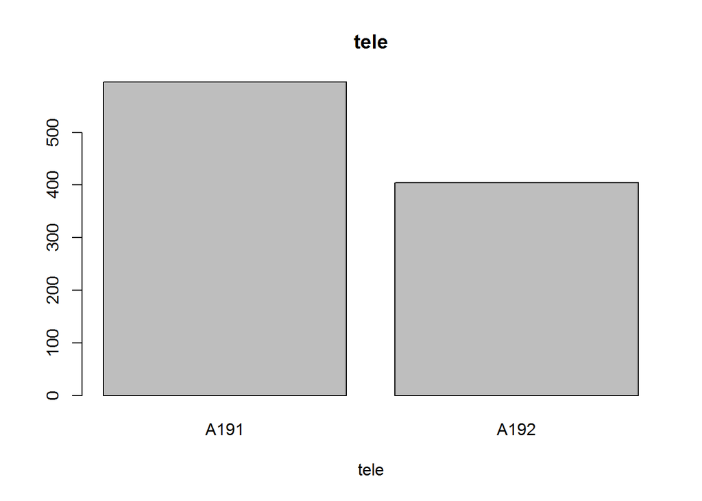

[1 more figures not shown]

```r
#Barplots for categorical varibales
for(i in 1:ncol(credit))
{
  if(is.factor(credit[,i]))
  {
     barplot(table(credit[,i]), main=names(credit)[i], xlab = names(credit)[i])
  }
}
```

**Bivariate Analysis**

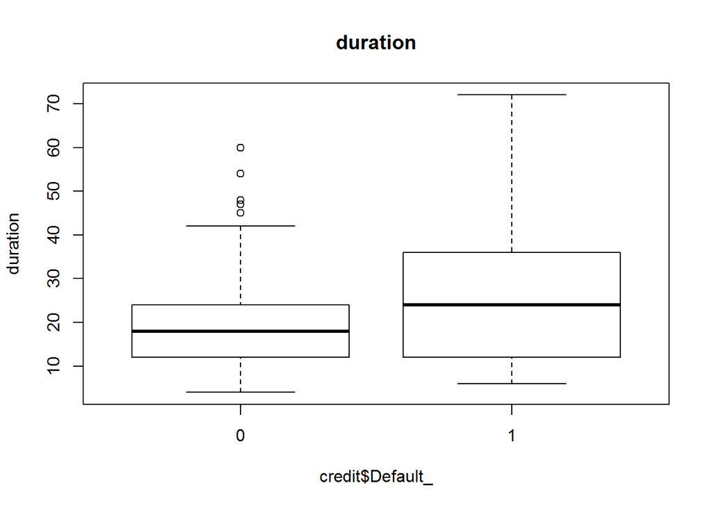

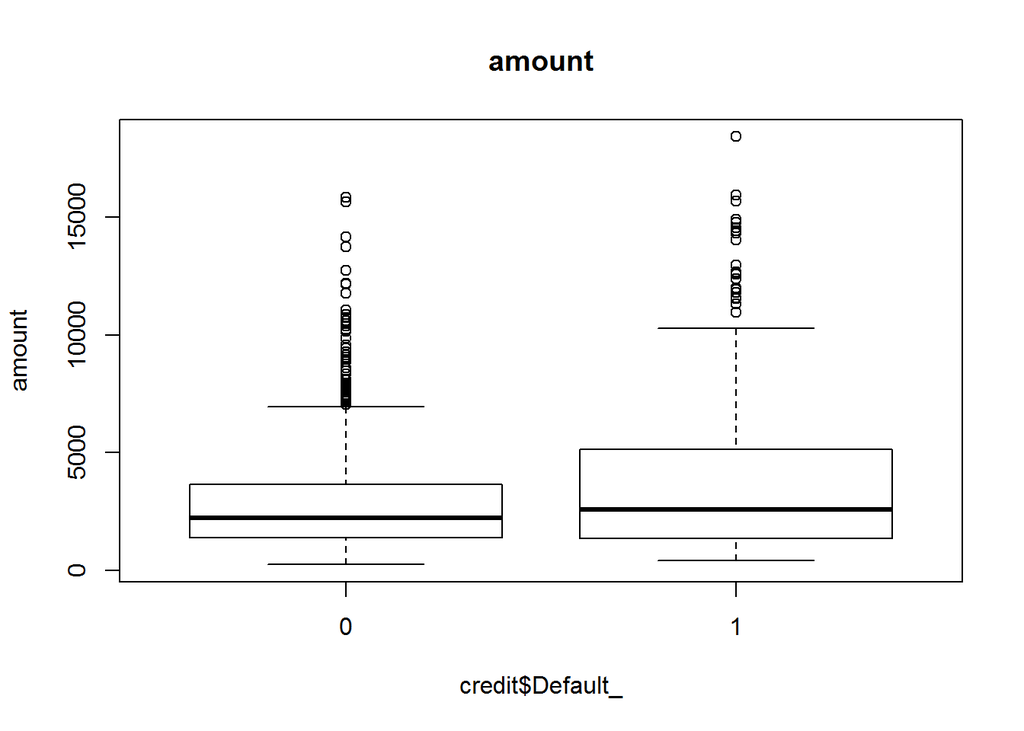

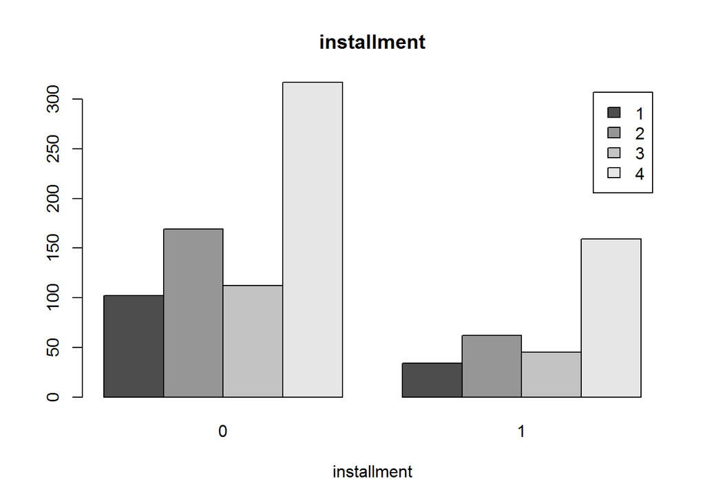

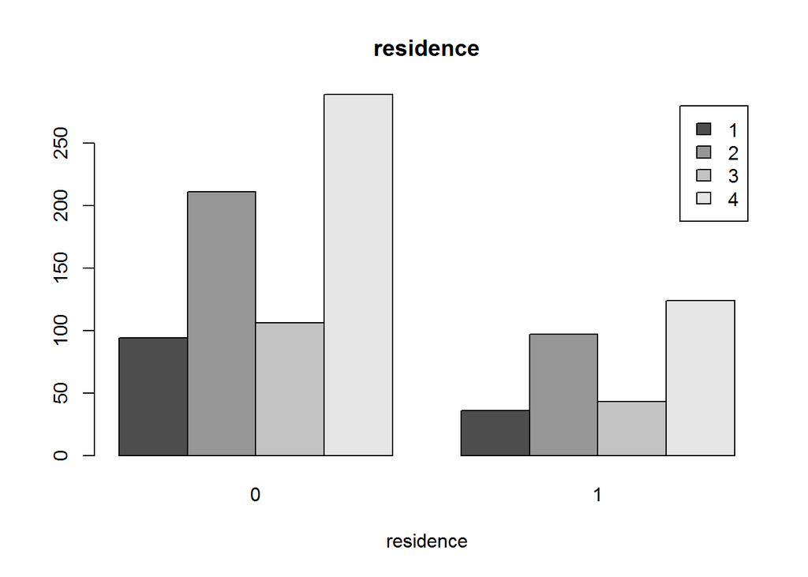

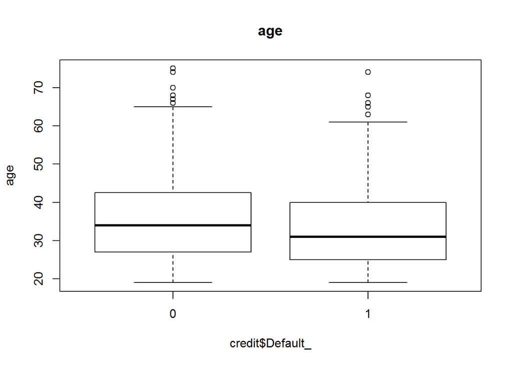

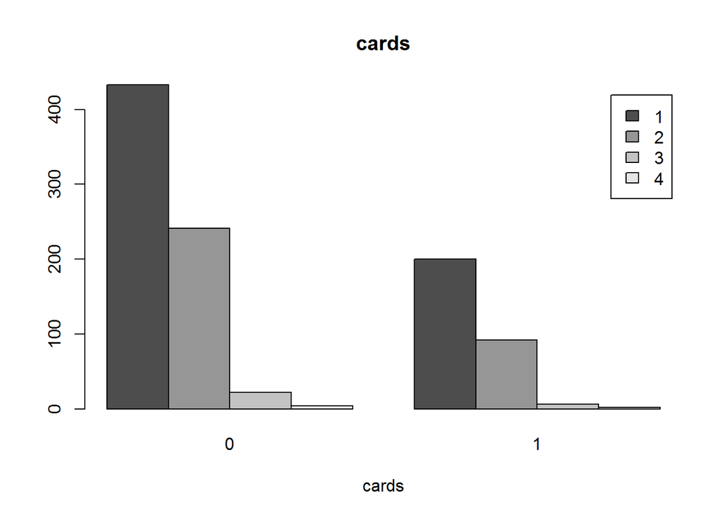

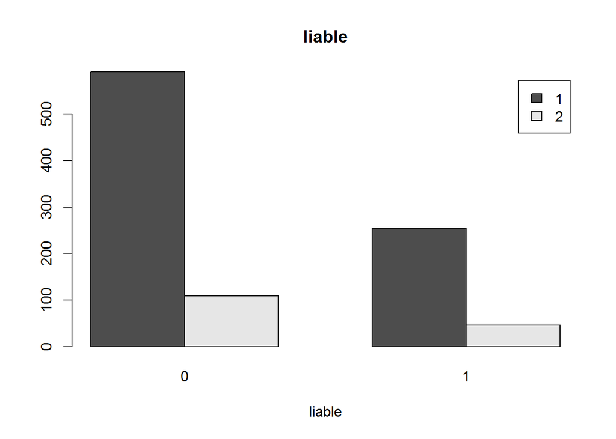

```r
#Side-by-side Boxplots for numerical variables
for(i in 2:ncol(credit))
{
  if(is.numeric(credit[,i]))
  {
    if(length(unique(credit[,i])) > 10)
    {
      boxplot(credit[,i] ~ credit$Default_, main = names(credit)[i], ylab = names(credit)[i])
    }

    else if(length(unique(credit[,i])) < 10)
    {
      barplot(table(credit[,i], credit$Default_), main=names(credit)[i],
              xlab = names(credit)[i], beside = T, legend = rownames(table(credit[,i])))
    }
  }
}
```

**Exporting the WOE Table for every categorical variables in excel workbook- WOE Table 2**

```r
wb = createWorkbook()

for(i in 2:ncol(credit))
{
  if(is.factor(credit[,i]))
  {

    varname = names(credit)[i]

    sheet = createSheet(wb, varname)

    woe = WOETable(credit[,varname], credit$Default_)

    addDataFrame(woe, sheet = sheet, startColumn = 2, row.names = F)

  }
}

saveWorkbook(wb, "WOE Table 2.xlsx")
```